# Assign6

Importing required libraries

```python
from tensorflow.keras.layers import Input, Dense, Flatten, Dropout, SimpleRNN, GRU, LSTM, GlobalMaxPool1D
from tensorflow.keras.models import Model
from tensorflow.keras.optimizers import SGD, Adam, RMSprop

import numpy as np
import pandas as pd
import matplotlib.pyplot as plt
import sys, os
```

Reading dataset from google drive

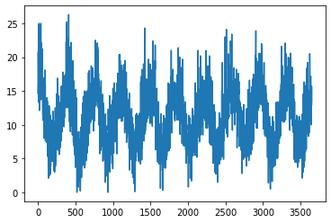

```python
!pip install -U -q PyDrive

#File ID
zip_id = '1WxkT_jgBlScTZVEmdE27VI0Bq0GPazyY'

from pydrive.auth import GoogleAuth
from pydrive.drive import GoogleDrive
from google.colab import auth
from oauth2client.client import GoogleCredentials
import zipfile, os

# Authenticate and create the PyDrive client.
auth.authenticate_user()
gauth = GoogleAuth()
gauth.credentials = GoogleCredentials.get_application_default()
drive = GoogleDrive(gauth)

# Download the zip file
myzip = drive.CreateFile({'id': zip_id})
myzip.GetContentFile('humidity.csv')

# Loading humidity dataset from csv
dataset = np.array(pd.read_csv('humidity.csv'))
dataset[0:5]
plt.plot(dataset)
```

Build the dataset

```python
T = 10
X = []
Y = []
for t in range(len(dataset) - T):
  x = dataset[t:t+T]  # Values from 0 to 9 (10values)
  X.append(x)         # First observation
  y = dataset[t+T]    # 10th value
  Y.append(y)         # append first Y

X = np.array(X).reshape(-1, T)      # T columns must have
Y = np.array(Y)
N = len(X)
print("X.shape", X.shape, "Y.shape", Y.shape)
```

```
X.shape (3640, 10) Y.shape (3640, 1)
```

**1) Autoregressive Linear Model**

Building the model

```python
#Build the autoregressive linear model
i = Input(shape=(T,))
x = Dense(1024,activation='relu')(i)
x = Dense(512)(x)
x = Dense(256)(x)
x = Dense(1)(x)
model = Model(i, x)

model.compile(
  loss='mse',
  optimizer=Adam(learning_rate=0.01),
  #optimizer=SGD(learning_rate=0.01,momentum=0.9)
)

#Training the model
r = model.fit(
  X[:N//2], Y[:N//2],     # First half for training
  epochs=100,
  validation_data=(X[N//2:], Y[N//2:]),  #Second half for valdiation
)
```

Loss plot

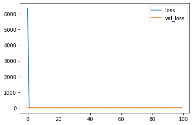

```python
# Plot loss per iteration
import matplotlib.pyplot as plt
plt.plot(r.history['loss'], label='loss')
plt.plot(r.history['val_loss'], label='val_loss')
plt.legend()
```

Forecasting plot

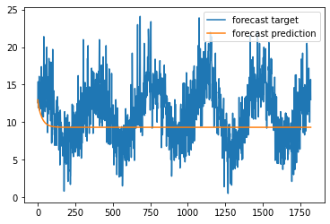

```python
validation_target = Y[N//2:]
validation_predictions = []

# first validation input
last_x = X[N//2] # 1-D array of length T  # Set the variable to be the first input vector because we need to take predicted values in consideration for prediction

while len(validation_predictions) < len(validation_target):
  p = model.predict(last_x.reshape(1, -1))[0,0] # 1x1 array -> scalar

  # update the predictions list
  validation_predictions.append(p)

  # make the new input
  last_x = np.roll(last_x, -1)      #Make the next new input with new predicted value append (shifting current X set to left and add current predicted value at end)
                                    #np.roll(x,-1) function shifts the values to left by 1 position and new value is appended at last index
  last_x[-1] = p

plt.plot(validation_target, label='forecast target')
plt.plot(validation_predictions, label='forecast prediction')
plt.legend()
```

**2) SimpleRNN**

Building the model

```python
#Build the Simple RNN Model
i = Input(shape=(T, 1))  #every sample is TXD
x = SimpleRNN(50,activation='relu')(i)      #Default activatoin is tanh    (try relu,none, hidden layers-15,50)
x = Dense(1024)(x)
x = Dense(1024)(x)
x = Dense(1024)(x)
x = Dense(512)(x)
x = Dense(256)(x)
x = Dense(128)(x)
x = Dense(1)(x)

model = Model(i, x)
model.compile(
  loss='mse',
  optimizer=Adam(learning_rate=0.001),
)

# train the Model
r = model.fit(
  X[:N//2], Y[:N//2],
  epochs=150,
  batch_size=32,
  validation_data=(X[N//2:], Y[N//2:]),
)
```

Loss plot

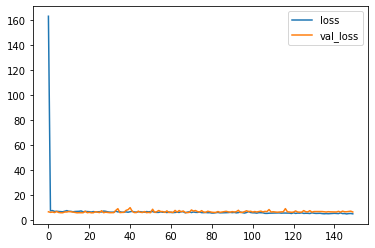

```python
# Plot loss per iteration
import matplotlib.pyplot as plt
plt.plot(r.history['loss'], label='loss')
plt.plot(r.history['val_loss'], label='val_loss')
plt.legend()
```

Forecasting plot

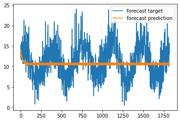

```python
# Forecast future values (use only self-predictions for making future predictions)

validation_target = Y[N//2:]
validation_predictions = []

# first validation input
last_x = X[N//2] # 1-D array of length T

while len(validation_predictions) < len(validation_target):
  p = model.predict(last_x.reshape(1, T, 1))[0,0] # 1x1 array -> scalar Input is shape N*T*D  output is N*K - desired is 1*T*1

  # update the predictions list
  validation_predictions.append(p)

  # make the new input
  last_x = np.roll(last_x, -1)
  last_x[-1] = p

plt.plot(validation_target, label='forecast target')
plt.plot(validation_predictions, label='forecast prediction')
plt.legend()
```

**3) GRU**

Building the model

```python
#Build the Simple RNN Model
i = Input(shape=(T, 1))  #every sample is TXD
x = GRU(100,activation='relu')(i)
x = Dense(1024)(x)
x = Dense(1024)(x)
x = Dense(1024)(x)
x = Dense(512)(x)
x = Dense(512)(x)
x = Dense(512)(x)
x = Dense(256)(x)
x = Dense(256)(x)
x = Dense(256)(x)
x = Dense(128)(x)
x = Dense(128)(x)
x = Dense(128)(x)
x = Dense(1)(x)

model = Model(i, x)
model.compile(
  loss='mse',
  optimizer=Adam(learning_rate=0.001),
)

# train the Model
r = model.fit(
  X[:N//2], Y[:N//2],
  batch_size=32,
  epochs=150,
  validation_data=(X[N//2:], Y[N//2:]),
)
```

```
WARNING:tensorflow:Layer gru_2 will not use cuDNN kernels since it doesn't meet the criteria. It will use a generic GPU kernel as fallback when running on GPU.
```

Loss plot

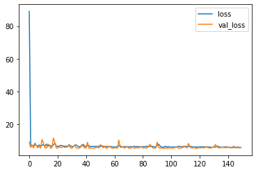

```python
# Plot loss per iteration
import matplotlib.pyplot as plt
plt.plot(r.history['loss'], label='loss')
plt.plot(r.history['val_loss'], label='val_loss')
plt.legend()
```

Forecasting plot

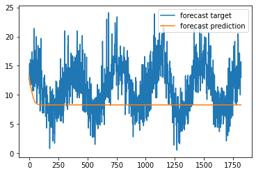

```python
# Forecast future values (use only self-predictions for making future predictions)

validation_target = Y[N//2:]
validation_predictions = []

# first validation input
last_x = X[N//2] # 1-D array of length T

while len(validation_predictions) < len(validation_target):
  p = model.predict(last_x.reshape(1, T, 1))[0,0] # 1x1 array -> scalar Input is shape N*T*D  output is N*K - desired is 1*T*1

  # update the predictions list
  validation_predictions.append(p)

  # make the new input
  last_x = np.roll(last_x, -1)
  last_x[-1] = p

plt.plot(validation_target, label='forecast target')
plt.plot(validation_predictions, label='forecast prediction')
plt.legend()
```

**4) LSTM**

Building the model

```python
#Build the Simple RNN Model
i = Input(shape=(T, 1))  #every sample is TXD
x = LSTM(100,activation='relu')(i)
x = Dense(2048)(x)
x = Dense(1024)(x)
x = Dense(1024)(x)
x = Dense(512)(x)
x = Dense(512)(x)
x = Dense(256)(x)
x = Dense(256)(x)
x = Dense(128)(x)
x = Dense(128)(x)
x = Dense(1)(x)

model = Model(i, x)
model.compile(
  loss='mse',
  optimizer=Adam(learning_rate=0.001),
)

# train the Model
r = model.fit(
  X[:N//2], Y[:N//2],
  epochs=100,
  batch_size=32,
  validation_data=(X[N//2:], Y[N//2:]),
)
```

```
WARNING:tensorflow:Layer lstm_1 will not use cuDNN kernels since it doesn't meet the criteria. It will use a generic GPU kernel as fallback when running on GPU.
```

Loss plot

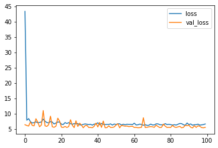

```python
# Plot loss per iteration
import matplotlib.pyplot as plt
plt.plot(r.history['loss'], label='loss')
plt.plot(r.history['val_loss'], label='val_loss')
plt.legend()
```

Forecasting plot

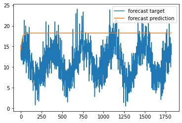

```python
# Forecast future values (use only self-predictions for making future predictions)

validation_target = Y[N//2:]
validation_predictions = []

# first validation input
last_x = X[N//2] # 1-D array of length T

while len(validation_predictions) < len(validation_target):
  p = model.predict(last_x.reshape(1, T, 1))[0,0] # 1x1 array -> scalar Input is shape N*T*D  output is N*K - desired is 1*T*1

  # update the predictions list
  validation_predictions.append(p)

  # make the new input
  last_x = np.roll(last_x, -1)
  last_x[-1] = p

plt.plot(validation_target, label='forecast target')
plt.plot(validation_predictions, label='forecast prediction')
plt.legend()
```

**5) LSTM with GlobalMaxPooling**

Building the model

```python
#Build the Simple RNN Model
i = Input(shape=(T, 1))  #every sample is TXD
x = LSTM(50,return_sequences=True,activation='relu')(i)
x = GlobalMaxPool1D()(x)
x = Dense(1024)(x)
x = Dense(512)(x)
x = Dense(256)(x)
x = Dense(128)(x)
x = Dense(1)(x)

model = Model(i, x)
model.compile(
  loss='mse',
  #optimizer=Adam(learning_rate=0.001),
  optimizer='rmsprop'
)

# train the Model
r = model.fit(
  X[:N//2], Y[:N//2],
  epochs=150,
  validation_data=(X[N//2:], Y[N//2:]),
)
```

```
WARNING:tensorflow:Layer lstm_2 will not use cuDNN kernels since it doesn't meet the criteria. It will use a generic GPU kernel as fallback when running on GPU.
```

Loss plot

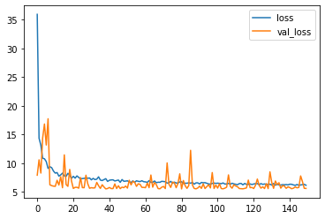

```python
# Plot loss per iteration
import matplotlib.pyplot as plt
plt.plot(r.history['loss'], label='loss')
plt.plot(r.history['val_loss'], label='val_loss')
plt.legend()
```

Forecasting plot

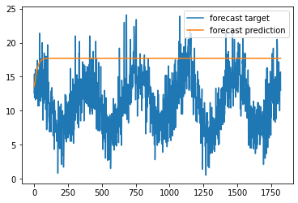

```python
# Forecast future values (use only self-predictions for making future predictions)

validation_target = Y[N//2:]
validation_predictions = []

# first validation input
last_x = X[N//2] # 1-D array of length T

while len(validation_predictions) < len(validation_target):
  p = model.predict(last_x.reshape(1, T, 1))[0,0] # 1x1 array -> scalar Input is shape N*T*D  output is N*K - desired is 1*T*1

  # update the predictions list
  validation_predictions.append(p)

  # make the new input
  last_x = np.roll(last_x, -1)
  last_x[-1] = p

plt.plot(validation_target, label='forecast target')
plt.plot(validation_predictions, label='forecast prediction')
plt.legend()
```

**Results**

**Autoregressive Linear Model** training_loss: 6.6410 validation_loss: 5.5965 The model is unable to detect the pattern.

**SimpleRNN model** training_loss: 4.7500 validation_loss: 6.2108 There is no major improvement in loss function for validation dataset but the model forecasting prediction improves slightly.

**GRU** training_loss: 5.9430 validation_loss: 5.9882 The validation loss improves slightly (loss plot is more smoother) and the model is able to detect the pattern initially.

**LSTM** training_loss: 6.6716 validation_loss: 5.5704 The model is able to detect the pattern initially but fails subsquently.

**LSTM with GlobalMaxPooling** training_loss: 6.1290 validation_loss: 5.5753 The model is able to detect the pattern initially but fails subsquently.